# Work through examples from [Veterinary Epidemiologic Research](http://www.upei.ca/ver/) in R.

We will work through the examples from the chapter on ‘Mixed models for discrete data’ (Pages 579-606) in the 2nd edition of the [Veterinary Epidemiologic Research](http://www.upei.ca/ver/) textbook. If you have the first edition of the same book the examples are almost the same and are on pages 499-520.

```r
pig_adg<- read.csv("pig_adg.csv")
```

Example 22.1 on page 581 illustrates the analysis of the association of atrophic rhinitis on pneumonia in pigs that are clustered in farms.

Let’s start by generating the necessary variables to do the analysis that the authors have done.

The authors have given us the `pn` variable already, presence or absence or pneumonia in the pig. We just need to generate the `ar_g1` variable that is presence of atrophic rhinitis with a score greater than 1.

```r
pig_adg$ar_g1 <- NA
pig_adg$ar_g1[pig_adg$ar > 1] <- 1
pig_adg$ar_g1[pig_adg$ar <= 1] <- 0
```

Then we can be neat and tidy and label the categorical variables that we are going to use

```r
pig_adg$ar_g1 <- factor(pig_adg$ar_g1, levels = c(0,1), labels = c("no atrophic", "yes atrophic"))

pig_adg$pn <- factor(pig_adg$pn, levels = c(0,1), labels = c("no pneumonia", "mild-severe pneumonia"))
```

Now we can do the cross-tabulation that they did

```r
table(pig_adg$pn, pig_adg$ar_g1)
```

```
                        no atrophic yes atrophic
  no pneumonia                   89           66
  mild-severe pneumonia          77          109
```

The authors also calculated odds ratio and tested the difference in proportions in the groups with a chi-square test. We can do that easily with the `epitools` library

## Contingency table

```r
library(epitools)

crosstab <- epitab(pig_adg$pn, pig_adg$ar_g1, pvalue = "chi2")
crosstab
```

```
$tab
                       Outcome
Predictor               no atrophic        p0 yes atrophic        p1
  no pneumonia                   89 0.5361446           66 0.3771429
  mild-severe pneumonia          77 0.4638554          109 0.6228571
                       Outcome
Predictor               oddsratio    lower    upper     p.value
  no pneumonia           1.000000       NA       NA          NA
  mild-severe pneumonia  1.908894 1.239452 2.939909 0.003205239

$measure
[1] "wald"

$conf.level
[1] 0.95

$pvalue
[1] "chi2"
```

From the above output we can see that the odds of a pig having pneumonia is 1.9088941 and that the calculated 95% confidence interval around that estimate is also available (1.2394525 - 2.9399085). The *P*-value that corresponds to the chi-sq is given (0.0032052) but not chi-sq statistic itself. Note that the confidence intervals and the *P*-values may not agree because the methods that the authors have used are not clear

The next thing that is done is a logistic regression with a random effect to adjust for the repeated measurement within farm. Before that, we will do the regression without the random effect:

## Mixed effects logistic regression

```r
model <- glm(pn ~ ar_g1, data = pig_adg, family = binomial)

summary(model)
```

```
Call:
glm(formula = pn ~ ar_g1, family = binomial, data = pig_adg)

Deviance Residuals:
    Min       1Q   Median       3Q      Max
-1.3965  -1.1166   0.9731   0.9731   1.2395

Coefficients:
                  Estimate Std. Error z value Pr(>|z|)
(Intercept)        -0.1448     0.1556  -0.931  0.35208
ar_g1yes atrophic   0.6465     0.2203   2.934  0.00334 **
---
Signif. codes:  0 '***' 0.001 '**' 0.01 '*' 0.05 '.' 0.1 ' ' 1

(Dispersion parameter for binomial family taken to be 1)

    Null deviance: 469.90  on 340  degrees of freedom
Residual deviance: 461.18  on 339  degrees of freedom
AIC: 465.18

Number of Fisher Scoring iterations: 4
```

Conveniently, in this function, we express the model in formula notation and the function takes an argument for the name of the dataset so you don’t have to write ´data$variablename´ for each variable you test. You also need to specify the model family, in this case it is a logistic regression and therefore, binomial. You can also confirm that the odds ratio from the cross tabulation that we did agrees with the estimate from the model. The coefficient (log odds) on Atrophic rhinitis is 0.6465241 and therefore the Odds ratio= e<sup>0.6465241</sup> = 1.9088941

Let’s now add the random effect for farm, we need to use another library `lme4` library to do this.

```r
library(lme4)

model2 <- glmer(pn ~ ar_g1 + (1 | farm), data = pig_adg, family = binomial)

summary(model2)
```

```
Generalized linear mixed model fit by maximum likelihood (Laplace
  Approximation) [glmerMod]
 Family: binomial  ( logit )
Formula: pn ~ ar_g1 + (1 | farm)
   Data: pig_adg

     AIC      BIC   logLik deviance df.resid
   433.3    444.8   -213.6    427.3      338

Scaled residuals:
    Min      1Q  Median      3Q     Max
-2.3022 -0.9195  0.3489  0.8044  2.0137

Random effects:
 Groups Name        Variance Std.Dev.
 farm   (Intercept) 0.8651   0.9301
Number of obs: 341, groups:  farm, 15

Fixed effects:
                  Estimate Std. Error z value Pr(>|z|)
(Intercept)        0.01886    0.29904   0.063   0.9497
ar_g1yes atrophic  0.43796    0.25712   1.703   0.0885 .
---
Signif. codes:  0 '***' 0.001 '**' 0.01 '*' 0.05 '.' 0.1 ' ' 1

Correlation of Fixed Effects:
            (Intr)
ar_g1ysatrp -0.431
```

Here you can see the notation used to add a random intercept to the model. `(1 | farm)`. Now the coefficient on the atrophic rhinitis has changed slightly after adjusting for the farm effect. The new adjusted odds ratio is ratio= e<sup>0.4379574</sup> = 1.5495389, however the estimate of the odds ratio is not significantly different from 1 as indicated by the *P*-value = 0.0885055. Also in the example the variance of the farm random effect is given. This is 0.8650887 and has a standard error that is different than the value given in the book because the method of calculation is different.

```r
model3 <- glmer(pn ~ ar_g1 + dtm  + (1 | farm), data = pig_adg, family = binomial)
```

```r
model4 <- glmer(pn ~ ar_g1 + log(dtm)  + (1 | farm), data = pig_adg, family = binomial)
```

or with the dummy variable:

```r
pig_adg$log_dtm <- log(pig_adg$dtm)

model5 <- glmer(pn ~ ar_g1 + log_dtm  + (1 | farm), data = pig_adg, family = binomial)

summary(model5)
```

```
Generalized linear mixed model fit by maximum likelihood (Laplace
  Approximation) [glmerMod]
 Family: binomial  ( logit )
Formula: pn ~ ar_g1 + log_dtm + (1 | farm)
   Data: pig_adg

     AIC      BIC   logLik deviance df.resid
   429.9    445.2   -210.9    421.9      337

Scaled residuals:
    Min      1Q  Median      3Q     Max
-2.7211 -0.8718  0.3774  0.7867  2.0191

Random effects:
 Groups Name        Variance Std.Dev.
 farm   (Intercept) 0.9113   0.9546
Number of obs: 341, groups:  farm, 15

Fixed effects:
                  Estimate Std. Error z value Pr(>|z|)
(Intercept)        -17.853      7.847  -2.275   0.0229 *
ar_g1yes atrophic    0.378      0.260   1.454   0.1460
log_dtm              3.419      1.500   2.279   0.0227 *
---
Signif. codes:  0 '***' 0.001 '**' 0.01 '*' 0.05 '.' 0.1 ' ' 1

Correlation of Fixed Effects:
            (Intr) ar_g1a
ar_g1ysatrp  0.082
log_dtm     -0.999 -0.098
```

If this was real life, I suppose we would consider the biological plausibility of the model that we have generated and look at the *P*-values and maybe throw out the ar_g1 variable and perhaps build a linear regression with days to market as the outcome and pneumonia as the independent variable…. This is just an example to teach you how to use R, so try to forget about whether or not the biology or modeling approach makes sense.

We need a dataframe of all the possible values of the covariates in order to predict the outcomes for all levels

## Predictions from regression

```r
adg_predict <- expand.grid(ar_g1 = levels(pig_adg$ar_g1),
                           dtm   = seq(min(pig_adg$dtm), max(pig_adg$dtm)),
                           farm  = sort(unique(pig_adg$farm)))

adg_predict$log_dtm <- log(adg_predict$dtm)
```

Have a look at the first few lines of this prediction dataframe

```r
head(adg_predict)
```

```
         ar_g1 dtm farm  log_dtm
1  no atrophic 141    1 4.948760
2 yes atrophic 141    1 4.948760
3  no atrophic 142    1 4.955827
4 yes atrophic 142    1 4.955827
5  no atrophic 143    1 4.962845
6 yes atrophic 143    1 4.962845
```

Make the predictions based on the `model5` model. In this case the `predict` function will use the `log_dtm` variable to do the prediction in the `adg_predict` dataframe to calculate the predicted log odds because the was the name of the variable when the model was specified.

```r
adg_predict$pred_model5 <- predict(model5, adg_predict)
```

We should get the same result if we do the prediction with `model4` and internally the predictions will be calculated based on the `dtm` variable and the `log` operation on the `dtm` value will be done by the model.

```r
adg_predict$pred_model4 <- predict(model4, adg_predict)
```

Have a look at the first few rows of the prediction dataframe `adg_predict`

```r
head(adg_predict)
```

```
         ar_g1 dtm farm  log_dtm pred_model5 pred_model4
1  no atrophic 141    1 4.948760   0.2693830   0.2693830
2 yes atrophic 141    1 4.948760   0.6473461   0.6473461
3  no atrophic 142    1 4.955827   0.2935456   0.2935456
4 yes atrophic 142    1 4.955827   0.6715088   0.6715088
5  no atrophic 143    1 4.962845   0.3175387   0.3175387
6 yes atrophic 143    1 4.962845   0.6955019   0.6955019
```

## Plot predictions

First we can plot the predictions with one line for each random intercept (each farm) and the lines coloured by the atrophic rhinitis variable.

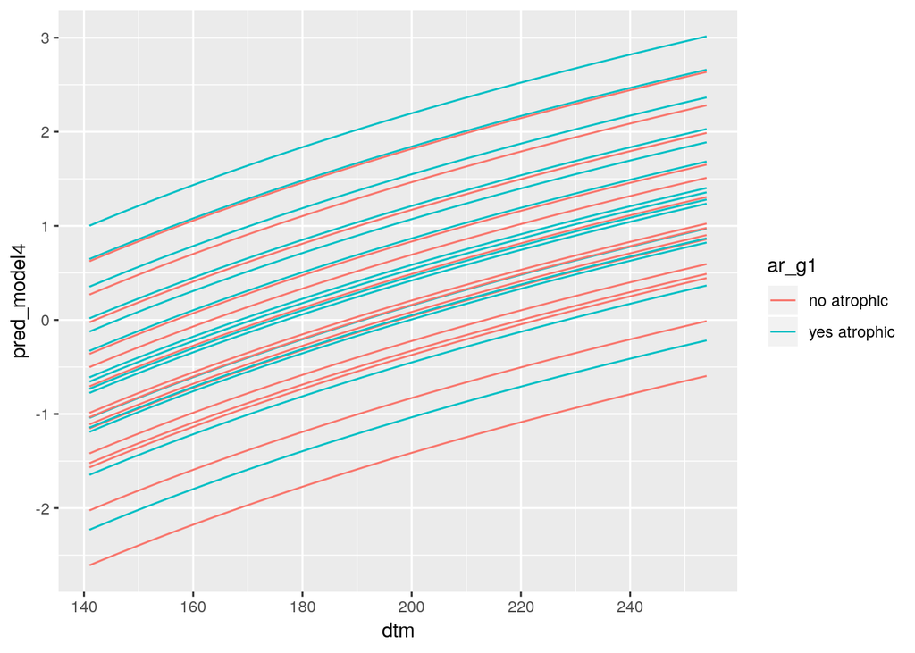

```r
library(ggplot2)

ggplot(adg_predict, aes(x = dtm, y = pred_model4, group = interaction(ar_g1, farm), colour = ar_g1)) +
    geom_line()
```

This illustrates the magnitude of the effect of herd compared to the other variables in the model. Not I guess it’s not too surprising that the effect of atrophic rhinitis on pneumonia was not significant after adjusting for farm. We can also just look at the model predictions for an average farm. The shape of the model is the same for all farms because we have no interactions with farm. Start by calculating the mean predictions for each `dtm` and `ar_g1` level across farms:

```r
library(plyr)
prediction2 <- ddply(.data = adg_predict, .variables = c("dtm", "ar_g1"), .fun = function(x){mean(x$pred_model4)})

head(prediction2)
```

```
  dtm        ar_g1         V1
1 141  no atrophic -0.9417826
2 141 yes atrophic -0.5638195
3 142  no atrophic -0.9176200
4 142 yes atrophic -0.5396569
5 143  no atrophic -0.8936269
6 143 yes atrophic -0.5156638
```

And plot this:

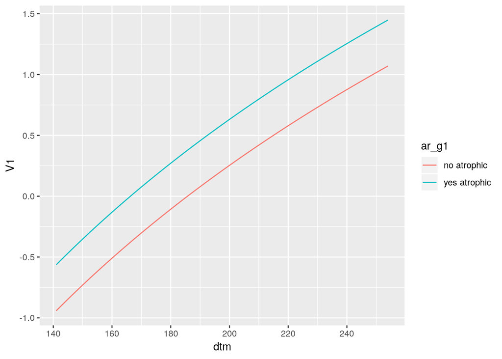

```r
ggplot(prediction2, aes(x = dtm, y = V1, group = ar_g1, colour = ar_g1)) +
    geom_line()
```

Maybe we want to view the predictions as predicted probability instead of on the log odds scale

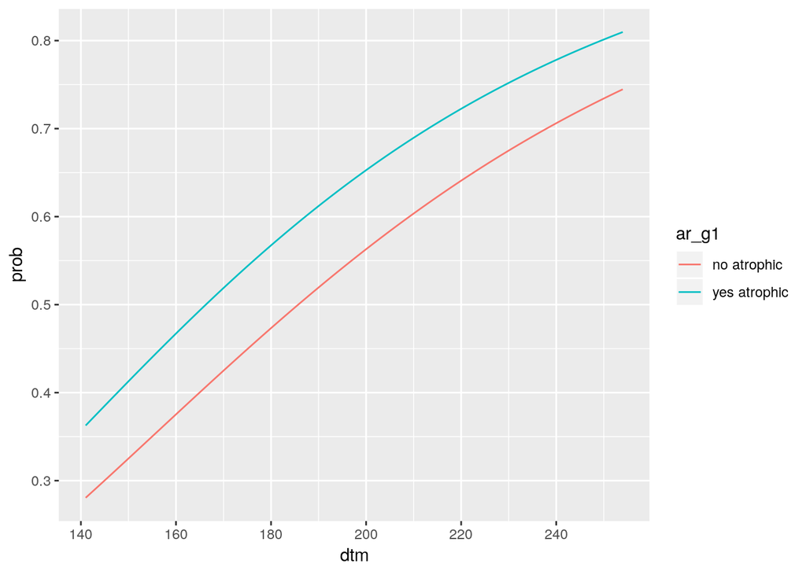

```r
prediction2$prob <- exp(prediction2$V1)/(1+exp(prediction2$V1))

ggplot(prediction2, aes(x = dtm, y = prob, group = ar_g1, colour = ar_g1)) +
    geom_line()
```

## Now you try

We are going to learn more about plotting with `ggplot2` in a later lesson so you don’t need to focus on that, but feel free to explore.

- Build a linear model with days to market as the outcome. You can choose which associations you would like to explore. Keep in mind that the `family` argument of the regression function will no longer be `binomial`.
- Try with and without a random intercept